# 08_EDA_AdultCensus

Antonio - Montilla - NEOLAND

22/11/2019

Basado en la última práctica EDA Titanic en R Studio (el fichero original así como el fichero HTML se encuentra en Google Drive), deben realizar una EDA completo para este dataset:

https://archive.ics.uci.edu/ml/datasets/adult

**IMPORTANTE**: Los pasos a realizar son: - exploración - limpieza - discretización - creación nuevos atributos - visualización con los gráficos de ggplot2 de las variables que consideran importantes - conclusiones justificadas sobre vuestra observaciones - posibilidad de agregar nuevos escenarios posibles (nuevas fuentes de datos, tipo de ingestas, otros aspectos de análisis, etc.) - Intentar crear el output de salida en formato HTML (buscar info de knit y sus dependencias)

### Cargamos las librerías

```r
library(ggplot2)
library(dplyr)
```

### Importando la database

```r
# Cargamos el juego de datos
datosAdult <- read.csv('http://archive.ics.uci.edu/ml/machine-learning-databases/adult/adult.data',stringsAsFactors = FALSE, header = FALSE)

# Nombres de los atributos
names(datosAdult) <- c("age","workclass","fnlwgt","education","education-num","marital-status","occupation","relationship","race","sex","capital-gain","capital-loss","hour-per-week","native-country","income")
```

### 1. Primer paso crear un backup de la database

```r
datosAdult_backup <- datosAdult
```

### 2. Explorando características principales del dataframe

```r
dim(datosAdult)
```

```
## [1] 32561    15
```

```r
str(datosAdult)
```

```
## 'data.frame':    32561 obs. of  15 variables:
##  $ age           : int  39 50 38 53 28 37 49 52 31 42 ...
##  $ workclass     : chr  " State-gov" " Self-emp-not-inc" " Private" " Private" ...
##  $ fnlwgt        : int  77516 83311 215646 234721 338409 284582 160187 209642 45781 159449 ...
##  $ education     : chr  " Bachelors" " Bachelors" " HS-grad" " 11th" ...
##  $ education-num : int  13 13 9 7 13 14 5 9 14 13 ...
##  $ marital-status: chr  " Never-married" " Married-civ-spouse" " Divorced" " Married-civ-spouse" ...
##  $ occupation    : chr  " Adm-clerical" " Exec-managerial" " Handlers-cleaners" " Handlers-cleaners" ...
##  $ relationship  : chr  " Not-in-family" " Husband" " Not-in-family" " Husband" ...
##  $ race          : chr  " White" " White" " White" " Black" ...
##  $ sex           : chr  " Male" " Male" " Male" " Male" ...
##  $ capital-gain  : int  2174 0 0 0 0 0 0 0 14084 5178 ...
##  $ capital-loss  : int  0 0 0 0 0 0 0 0 0 0 ...
##  $ hour-per-week : int  40 13 40 40 40 40 16 45 50 40 ...
##  $ native-country: chr  " United-States" " United-States" " United-States" " United-States" ...
##  $ income        : chr  " <=50K" " <=50K" " <=50K" " <=50K" ...
```

```r
head(datosAdult[1:5], n = 10)
```

```
##    age         workclass fnlwgt  education education-num
## 1   39         State-gov  77516  Bachelors            13
## 2   50  Self-emp-not-inc  83311  Bachelors            13
## 3   38           Private 215646    HS-grad             9
## 4   53           Private 234721       11th             7
## 5   28           Private 338409  Bachelors            13
## 6   37           Private 284582    Masters            14
## 7   49           Private 160187        9th             5
## 8   52  Self-emp-not-inc 209642    HS-grad             9
## 9   31           Private  45781    Masters            14
## 10  42           Private 159449  Bachelors            13
```

```r
head(datosAdult[6:10], n = 10)
```

```
##            marital-status         occupation   relationship   race     sex
## 1           Never-married       Adm-clerical  Not-in-family  White    Male
## 2      Married-civ-spouse    Exec-managerial        Husband  White    Male
## 3                Divorced  Handlers-cleaners  Not-in-family  White    Male
## 4      Married-civ-spouse  Handlers-cleaners        Husband  Black    Male
## 5      Married-civ-spouse     Prof-specialty           Wife  Black  Female
## 6      Married-civ-spouse    Exec-managerial           Wife  White  Female
## 7   Married-spouse-absent      Other-service  Not-in-family  Black  Female
## 8      Married-civ-spouse    Exec-managerial        Husband  White    Male
## 9           Never-married     Prof-specialty  Not-in-family  White  Female
## 10     Married-civ-spouse    Exec-managerial        Husband  White    Male
```

```r
head(datosAdult[11:15], n= 10)
```

```
##    capital-gain capital-loss hour-per-week native-country income
## 1          2174            0            40  United-States  <=50K
## 2             0            0            13  United-States  <=50K
## 3             0            0            40  United-States  <=50K
## 4             0            0            40  United-States  <=50K
## 5             0            0            40           Cuba  <=50K
## 6             0            0            40  United-States  <=50K
## 7             0            0            16        Jamaica  <=50K
## 8             0            0            45  United-States   >50K
## 9         14084            0            50  United-States   >50K
## 10         5178            0            40  United-States   >50K
```

#### Posible preguntas exploratorias:

- El nivel educativo es un determinante del nivel de ingreso?
- La raza importa en el nivel de ingreso?
- Y el pais de origen?
- Las personas casadas tienden a tener menos ingresos?
- Realmente hay dicriminación de género en cuanto al ingreso en USA?
- Se observa una brecha de ingreso entre trabajadores del Estado vs. privados?
- Y en terminos de autónomos y empleados?

### 3. Limpieza: Explorar precensia de NAs en los datos

```r
colSums(is.na(datosAdult))
```

```
##            age      workclass         fnlwgt      education  education-num
##              0              0              0              0              0
## marital-status     occupation   relationship           race            sex
##              0              0              0              0              0
##   capital-gain   capital-loss  hour-per-week native-country         income
##              0              0              0              0              0
```

#### La exploración confirma no existen NAs en la dataset

### 4. Limpieza: missing values

```r
colSums(datosAdult=="")
```

```
##            age      workclass         fnlwgt      education  education-num
##              0              0              0              0              0
## marital-status     occupation   relationship           race            sex
##              0              0              0              0              0
##   capital-gain   capital-loss  hour-per-week native-country         income
##              0              0              0              0              0
```

### 5. Explorando frecuencias por variables

```r
prop.table(table(datosAdult$income))
```

```
##
##     <=50K      >50K
## 0.7591904 0.2408096
```

```r
table(datosAdult$age)
```

```
##
##  17  18  19  20  21  22  23  24  25  26  27  28  29  30  31  32  33  34
## 395 550 712 753 720 765 877 798 841 785 835 867 813 861 888 828 875 886
##  35  36  37  38  39  40  41  42  43  44  45  46  47  48  49  50  51  52
## 876 898 858 827 816 794 808 780 770 724 734 737 708 543 577 602 595 478
##  53  54  55  56  57  58  59  60  61  62  63  64  65  66  67  68  69  70
## 464 415 419 366 358 366 355 312 300 258 230 208 178 150 151 120 108  89
##  71  72  73  74  75  76  77  78  79  80  81  82  83  84  85  86  87  88
##  72  67  64  51  45  46  29  23  22  22  20  12   6  10   3   1   1   3
##  90
##  43
```

```r
prop.table(table(datosAdult$workclass))
```

```
##
##                 ?       Federal-gov         Local-gov      Never-worked
##      0.0563864746      0.0294831240      0.0642793526      0.0002149811
##           Private      Self-emp-inc  Self-emp-not-inc         State-gov
##      0.6970301895      0.0342741316      0.0780381438      0.0398636406
##       Without-pay
##      0.0004299622
```

```r
prop.table(table(datosAdult$education))
```

```
##
##          10th          11th          12th       1st-4th       5th-6th
##   0.028653911   0.036086115   0.013298117   0.005159547   0.010226959
##       7th-8th           9th    Assoc-acdm     Assoc-voc     Bachelors
##   0.019839686   0.015785756   0.032769264   0.042443414   0.164460551
##     Doctorate       HS-grad       Masters     Preschool   Prof-school
##   0.012683886   0.322502380   0.052916065   0.001566291   0.017689874
##  Some-college
##   0.223918184
```

```r
prop.table(table(datosAdult$`education-num`))
```

```
##
##           1           2           3           4           5           6
## 0.001566291 0.005159547 0.010226959 0.019839686 0.015785756 0.028653911
##           7           8           9          10          11          12
## 0.036086115 0.013298117 0.322502380 0.223918184 0.042443414 0.032769264
##          13          14          15          16
## 0.164460551 0.052916065 0.017689874 0.012683886
```

```r
prop.table(table(datosAdult$`native-country`))
```

```
##
##                           ?                    Cambodia
##                1.790486e-02                5.835202e-04
##                      Canada                       China
##                3.716102e-03                2.303369e-03
##                    Columbia                        Cuba
##                1.811984e-03                2.917601e-03
##          Dominican-Republic                     Ecuador
##                2.149811e-03                8.599244e-04
##                 El-Salvador                     England
##                3.255428e-03                2.764043e-03
##                      France                     Germany
##                8.906360e-04                4.207487e-03
##                      Greece                   Guatemala
##                8.906360e-04                1.965542e-03
##                       Haiti          Holand-Netherlands
##                1.351310e-03                3.071159e-05
##                    Honduras                        Hong
##                3.992506e-04                6.142317e-04
##                     Hungary                       India
##                3.992506e-04                3.071159e-03
##                        Iran                     Ireland
##                1.320598e-03                7.370781e-04
##                       Italy                     Jamaica
##                2.241946e-03                2.487639e-03
##                       Japan                        Laos
##                1.904118e-03                5.528086e-04
##                      Mexico                   Nicaragua
##                1.974755e-02                1.044194e-03
##  Outlying-US(Guam-USVI-etc)                        Peru
##                4.299622e-04                9.520592e-04
##                 Philippines                      Poland
##                6.080894e-03                1.842695e-03
##                    Portugal                 Puerto-Rico
##                1.136329e-03                3.501121e-03
##                    Scotland                       South
##                3.685390e-04                2.456927e-03
##                      Taiwan                    Thailand
##                1.566291e-03                5.528086e-04
##             Trinadad&Tobago               United-States
##                5.835202e-04                8.958570e-01
##                     Vietnam                  Yugoslavia
##                2.057676e-03                4.913854e-04
```

```r
prop.table(table(datosAdult$`marital-status`))
```

```
##
##               Divorced      Married-AF-spouse     Married-civ-spouse
##           0.1364515832           0.0007063665           0.4599367341
##  Married-spouse-absent          Never-married              Separated
##           0.0128374436           0.3280918891           0.0314793772
##                Widowed
##           0.0304966064
```

```r
prop.table(table(datosAdult$occupation))
```

```
##
##                  ?       Adm-clerical       Armed-Forces
##       0.0566014557       0.1157826848       0.0002764043
##       Craft-repair    Exec-managerial    Farming-fishing
##       0.1258867971       0.1248733147       0.0305273180
##  Handlers-cleaners  Machine-op-inspct      Other-service
##       0.0420748749       0.0614845981       0.1011946808
##    Priv-house-serv     Prof-specialty    Protective-serv
##       0.0045760265       0.1271459722       0.0199318203
##              Sales       Tech-support   Transport-moving
##       0.1120972943       0.0285003532       0.0490464052
```

### 6. Discretrizando las variables

```r
apply(datosAdult, MARGIN = 2, FUN = function(x) length(unique(x)))
```

```
##            age      workclass         fnlwgt      education  education-num
##             73              9          21648             16             16
## marital-status     occupation   relationship           race            sex
##              7             15              6              5              2
##   capital-gain   capital-loss  hour-per-week native-country         income
##            119             92             94             42              2
```

Ahora procedo a factorizar las string variables con pocas clases (en función al análisis exploratorio). Estas son: ‘workclass’, ‘marital-status’, ‘race’ y ‘sex’

```r
cols1 <- c("workclass", "marital-status", "race", "sex")
for (i in cols1){
  datosAdult[,i] = as.factor(datosAdult[,i])
}
str(datosAdult)
```

```
## 'data.frame':    32561 obs. of  15 variables:
##  $ age           : int  39 50 38 53 28 37 49 52 31 42 ...
##  $ workclass     : Factor w/ 9 levels " ?"," Federal-gov",..: 8 7 5 5 5 5 5 7 5 5 ...
##  $ fnlwgt        : int  77516 83311 215646 234721 338409 284582 160187 209642 45781 159449 ...
##  $ education     : chr  " Bachelors" " Bachelors" " HS-grad" " 11th" ...
##  $ education-num : int  13 13 9 7 13 14 5 9 14 13 ...
##  $ marital-status: Factor w/ 7 levels " Divorced"," Married-AF-spouse",..: 5 3 1 3 3 3 4 3 5 3 ...
##  $ occupation    : chr  " Adm-clerical" " Exec-managerial" " Handlers-cleaners" " Handlers-cleaners" ...
##  $ relationship  : chr  " Not-in-family" " Husband" " Not-in-family" " Husband" ...
##  $ race          : Factor w/ 5 levels " Amer-Indian-Eskimo",..: 5 5 5 3 3 5 3 5 5 5 ...
##  $ sex           : Factor w/ 2 levels " Female"," Male": 2 2 2 2 1 1 1 2 1 2 ...
##  $ capital-gain  : int  2174 0 0 0 0 0 0 0 14084 5178 ...
##  $ capital-loss  : int  0 0 0 0 0 0 0 0 0 0 ...
##  $ hour-per-week : int  40 13 40 40 40 40 16 45 50 40 ...
##  $ native-country: chr  " United-States" " United-States" " United-States" " United-States" ...
##  $ income        : chr  " <=50K" " <=50K" " <=50K" " <=50K" ...
```

### 7. Creación de nuevos atributos

#### Pais de procedencia

Con respecto a ‘native-country’, creo una nueva variable que denominada ‘US_native’ tomando 1 si individuo es originario de USA y 0 si no. Factorizo la nueva variable.

```r
datosAdult$US_native <- ifelse(datosAdult$`native-country` ==' United-States', 1, 0)
table(datosAdult$US_native)
```

```
##
##     0     1
##  3391 29170
```

```r
datosAdult$US_native = as.factor(datosAdult$US_native)
```

#### Nivel de ingreso

Igualmente, creo una nueva variable denominada ‘Income_50’ que sea 1 si ingreso es ‘>50’ o 0 si ‘<50’ usando columna ‘income’. Factorizo la nueva variable.

```r
datosAdult$Income_50 <- ifelse(datosAdult$income == " >50K", 1, 0)
table(datosAdult$Income_50)
```

```
##
##     0     1
## 24720  7841
```

```r
str(datosAdult$Income_50)
```

```
##  num [1:32561] 0 0 0 0 0 0 0 1 1 1 ...
```

```r
datosAdult$Income_50 = as.factor(datosAdult$Income_50)
```

#### Raza

También creo una variable de raza ‘White’ que toma 1 si race es blanco y 0 si no. Factorizo la nueva variable.

```r
datosAdult$White <- ifelse(datosAdult$race == ' White', 1, 0)
table(datosAdult$White)
```

```
##
##     0     1
##  4745 27816
```

```r
datosAdult$White = as.factor(datosAdult$White)
```

### 8. Análisis Conjunto de Datos y Conclusiones

#### El nivel educativo esta asociado con el nivel de ingreso?

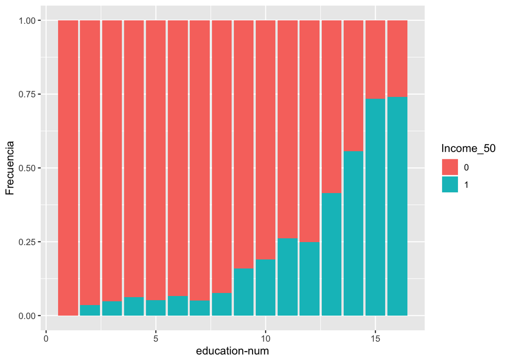

```r
fila = dim(datosAdult)[1]
ggplot(data=datosAdult[1:fila,], aes(x=`education-num`, fill=`Income_50`))+geom_bar(position="fill")+ylab("Frecuencia")
```

Hay una clara correlación positiva entre el número de años en educación con el nivel de ingreso, i.e. la probabilidad de que un individuo gane > $50k anuales crece en función a los años de estudio

#### La raza importa en el nivel de ingreso?

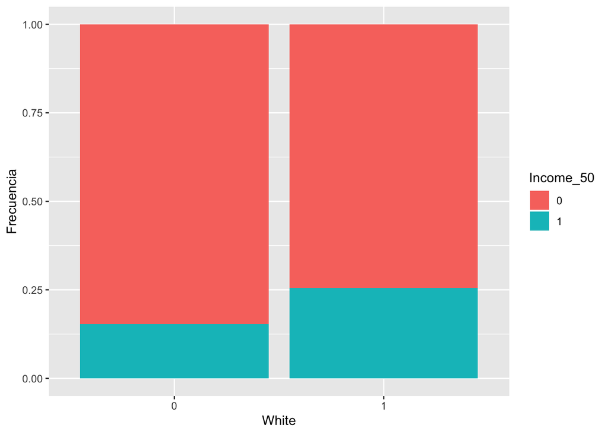

```r
ggplot(data=datosAdult[1:fila,], aes(x=White, fill=`Income_50`))+geom_bar(position="fill")+ylab("Frecuencia")
```

Los individuos blancos en USA tienen una mayor probabilidad de ganar ingresos superiores a los no blancos, sin embargo la brecha no es sustancial. Requiere mayor investigación (e.g. distribución de ingreso, ingreso medio), sin embargo, a priori, los datos no sugieren una gran discriminación respecto a la raza.

#### Y el pais de origen?

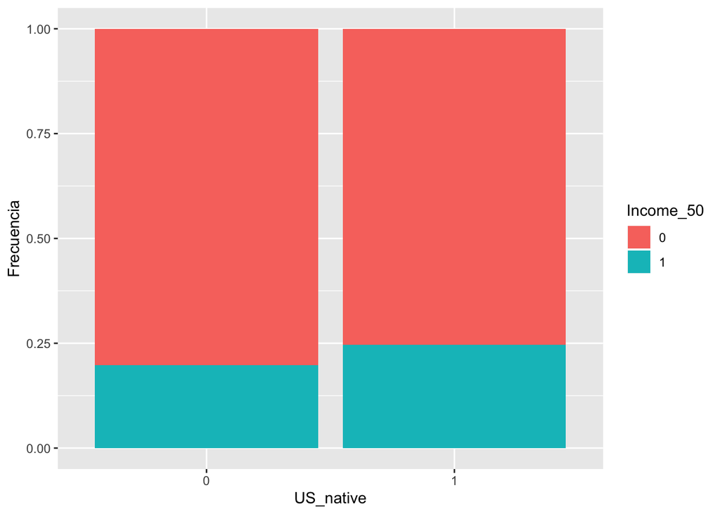

```r
ggplot(data=datosAdult[1:fila,], aes(x=US_native, fill=`Income_50`))+geom_bar(position="fill")+ylab("Frecuencia")
```

Ser procediente de USA incide marginalmente en la probabilidad de percibir ingresos > $50k versus individuos procedentes de otros paises.

#### Quienes son los grupos de edad que tienden a percibir mayores ingresos?

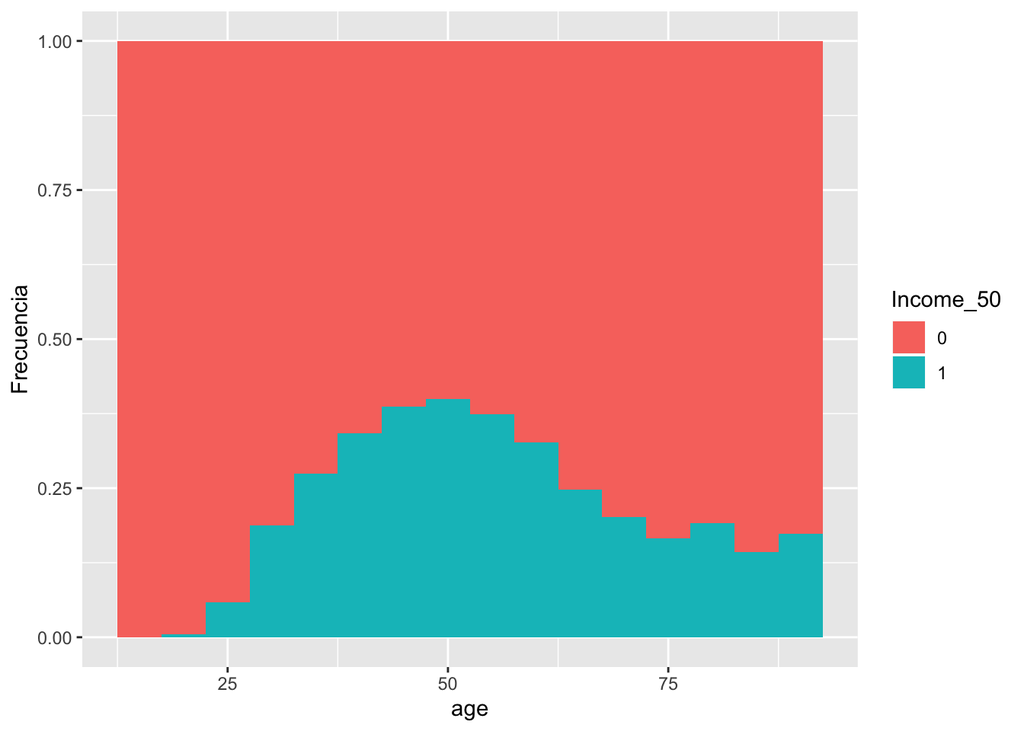

```r
ggplot(data = datosAdult[!(is.na(datosAdult[1:fila,]$age)),],
       aes (x=age, fill=Income_50))+geom_histogram(binwidth = 5, position = 'fill')+
  ylab("Frecuencia")
```

Los individuos concentrados en la mediana de la población economicamente activa son los que tienen una mayor incidencia en percibir ingresos >$50k anuales.

Es decir: la probabilidad de que un individuo gane >$50k al año tiende a incrementarse desde que ingresa al mercado laboral (i.e. 17-18 años) hasta que alcanza 50-55 años. A partir de alli, los individuos tieden a percibir menos ingresos.

#### Las personas casadas tienden a tener menos ingresos?

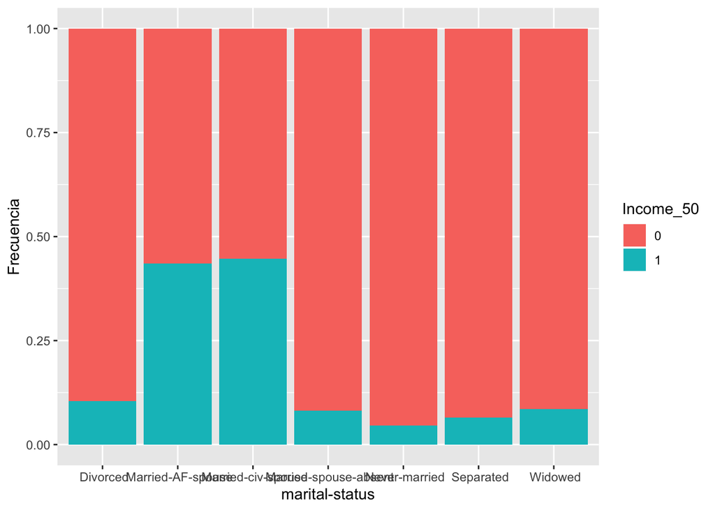

```r
ggplot(data=datosAdult[1:fila,], aes(x=`marital-status`, fill=`Income_50`))+geom_bar(position="fill")+ylab("Frecuencia")
```

```r
table(datosAdult$`marital-status`)
```

```
##
##               Divorced      Married-AF-spouse     Married-civ-spouse
##                   4443                     23                  14976
##  Married-spouse-absent          Never-married              Separated
##                    418                  10683                   1025
##                Widowed
##                    993
```

En USA, si un individuo está civilmente casado(a), tiene una probabilidad sustancialmente superior de percibir ingresos >$50K anuales que aquellos individuos no casados (e.g. divorciados, separados, viudos)

#### Realmente hay dicriminación de género en cuanto al ingreso en USA?

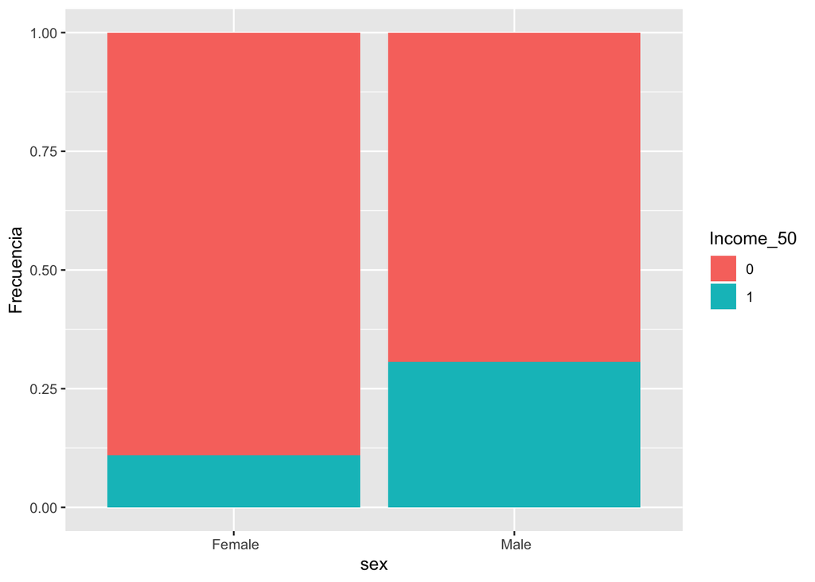

```r
ggplot(data=datosAdult[1:fila,], aes(x=sex, fill=`Income_50`))+geom_bar(position="fill")+ylab("Frecuencia")
```

Ser de género masculino en USA incrementa notablemente la probablidad de percibir ingresos >$50k anuales versus al género femenino.

#### Se observa una brecha de ingreso entre trabajadores del Estado vs. privados?

#### Y en terminos de autónomos y empleados?

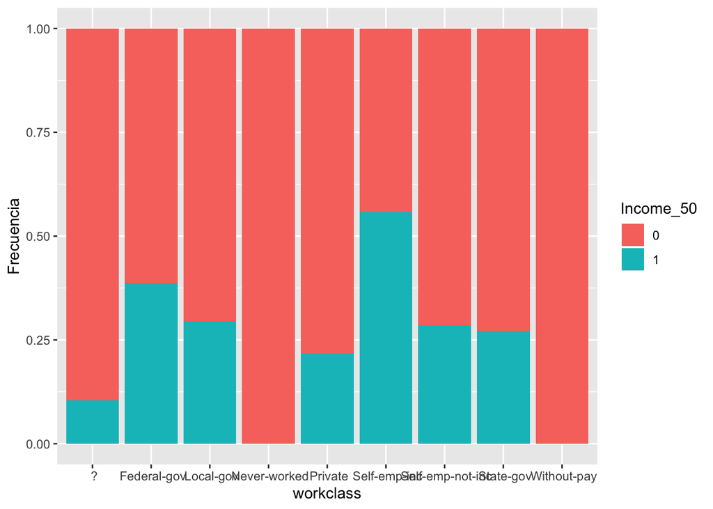

```r
ggplot(data=datosAdult[1:fila,], aes(x=workclass, fill=`Income_50`))+geom_bar(position="fill")+ylab("Frecuencia")
```

```r
table(datosAdult$workclass)
```

```
##
##                 ?       Federal-gov         Local-gov      Never-worked
##              1836               960              2093                 7
##           Private      Self-emp-inc  Self-emp-not-inc         State-gov
##             22696              1116              2541              1298
##       Without-pay
##                14
```

Los empleados públicos (en el agregado) tienen una probabilidad de percibir ingresos >$50k anuales superior a los empleados privados. Sin embargo, en USA, los individuos autónomos (que, naturalmente, incluye a los dueños del capital, i.e. empresas, negocios) son los que tienen una mayor incidencia de percibir ingresos >$50k anuales.